# Measuring the IQ of your Threat Intelligence - Summer 2014

Alex Pinto & Kyle Maxwell

August 5, 2014 (Last updated October 19, 2014)

This is the companion R Markdown document to the following presentations that were delivered in Summer 2014:

- BSides LV 2014 - “Measuring the IQ of your threat intelligence feeds”
- DEF CON 22 - “Measuring the IQ of your threat intelligence feeds”
- OpenDNS S4 IRespond - “Measuring the IQ of your threat intelligence feeds”
- HushCon 2014 - “Measuring the IQ of your threat intelligence feeds”

The slides deck for these talks is located [here](http://bitly.com/tiqtest)

It should provide enough examples for usage of the tools implemented at TIQ-test. Please review our [github repository page](https://github.com/mlsecproject/tiq-test), report bugs and suggest features!

Adding the TIQ-TEST functions

```r
## Some limitations from not being an R package: Setting the Working directory
tiqtest.dir = file.path("..", "tiq-test")
current.dir = setwd(tiqtest.dir)
source("tiq-test.R")

## Setting the root data path to where it should be in this repo
.tiq.data.setRootPath(file.path(current.dir, "data"))
```

```
## INFO [2015-02-01 13:23:39 PST] pid=1036 tiq.data.setRootPath: Setting path to '/Users/alexcp/src/tiq-test-Summer2014/data'
```

## Acessing the data using TIQ-TEST

We can use the `tiq.data` functions to load the Threat Intelligence datasets from the database for exploration using R. We have defaulted to the use of `data.table` objects for this because they are faster and you can write tighter code around it (sorry Hadleyverse fans).

We have roughly a month of data available on this public dataset:

```r
tiq.data.getAvailableDates("raw", "public_outbound")
```

```
##  [1] "20140615" "20140616" "20140617" "20140618" "20140619" "20140620"
##  [7] "20140621" "20140622" "20140623" "20140624" "20140625" "20140626"
## [13] "20140627" "20140628" "20140629" "20140630" "20140701" "20140702"
## [19] "20140703" "20140704" "20140705" "20140706" "20140707" "20140708"
## [25] "20140709" "20140710" "20140711" "20140712" "20140713" "20140714"
## [31] "20140715"
```

This is an example of “RAW” (not enriched) outbound data imported from combine output

```r
outbound.ti = tiq.data.loadTI("raw", "public_outbound", "20140701")
outbound.ti[, list(entity, type, direction, source, date)]
```

```
##                      entity type direction     source       date
##     1:         1.224.163.26 IPv4  outbound alienvault 2014-07-01
##     2:         1.242.99.155 IPv4  outbound alienvault 2014-07-01
##     3:           1.85.2.118 IPv4  outbound alienvault 2014-07-01
##     4:           1.93.1.162 IPv4  outbound alienvault 2014-07-01
##     5:         1.93.161.204 IPv4  outbound alienvault 2014-07-01
##    ---
## 16298:         winscoft.com FQDN  outbound       zeus 2014-07-01
## 16299:           wmzbase.ru FQDN  outbound       zeus 2014-07-01
## 16300:       zhabademon.net FQDN  outbound       zeus 2014-07-01
## 16301: zhangleetranding.com FQDN  outbound       zeus 2014-07-01
## 16302:         znatnydom.by FQDN  outbound       zeus 2014-07-01
```

This specific outbound dataset has the following sources included:

```r
outbound.ti = tiq.data.loadTI("raw", "public_outbound", "20140701")
unique(outbound.ti$source)
```

```
##  [1] "alienvault"        "botscout"          "malcode"
##  [4] "malcode_zones"     "malwaredomainlist" "malwaredomains"
##  [7] "malwaregroup"      "palevotracker"     "spyeye"
## [10] "zeus"
```

We can do the same for the inbound data we have to see the sources we have available:

```r
inbound.ti = tiq.data.loadTI("raw", "public_inbound", "20140701")
unique(inbound.ti$source)
```

```
##  [1] "alienvault"        "autoshun"          "blocklistde"
##  [4] "bruteforceblocker" "charleshaley"      "ciarmy"
##  [7] "dragonresearch"    "dshield"           "honeypot"
## [10] "openbl"            "packetmail"        "virbl"
```

SIDE NOTE: please don’t add non-malicious domains to malware domain lists, ok? :)

```r
outbound.ti = tiq.data.loadTI("raw", "public_outbound", "20140701")
outbound.ti[entity %like% "google.com", list(entity, type, direction, source, date)]
```

```
##               entity type direction         source       date
## 1: chrome.google.com FQDN  outbound malwaredomains 2014-07-01
```

We can use the same `loadTI` function to also gather the enriched datasets:

```r
enrich.ti = tiq.data.loadTI("enriched", "public_outbound", "20140710")
enrich.ti = enrich.ti[, notes := NULL]
enrich.ti[c(2,22264, 22266)]
```

```
##            entity type direction     source       date asnumber
## 1:   1.224.163.26 IPv4  outbound alienvault 2014-07-10     9318
## 2: 95.181.178.177 IPv4  outbound       zeus 2014-07-10    57311
## 3: 98.131.185.136 IPv4  outbound       zeus 2014-07-10    32392
##                                    asname country
## 1:                    Hanaro Telecom Inc.      KR
## 2: FOP ILIUSHENKO VOLODYMYR OLEXANDROVUCH      GB
## 3:                  Ecommerce Corporation      US
##                          host                   rhost
## 1:                         NA                      NA
## 2:           newdomaininfo.ru host178-177.neohost.net
## 3: projects.globaltronics.net                      NA
```

## Novelty Test

The novelty test should be used to try get a sense of the ratio of new indicators and the retiring of old ones as the data feeds progresses day-by-day.

There is no intrinsic right or wrong, but less frequent updates usually means that they are carefully curated (or abandoned :) ). Curated is great, abandoned is very bad.

Here are some results of running the Novelty test on the inbound data:

```r
inbound.novelty = tiq.test.noveltyTest("public_inbound", "20140615", "20140715",
                                select.sources=c("alienvault", "blocklistde",
                                                 "dshield", "charleshaley"),
                                                                         .progress=FALSE)
```

```
## WARN [2015-02-01 13:23:54 PST] pid=1036 tiq.data.loadTI: path '/Users/alexcp/src/tiq-test-Summer2014/data/raw/public_inbound/20140621.csv.gz' is invalid. No data available on date '20140621'.
```

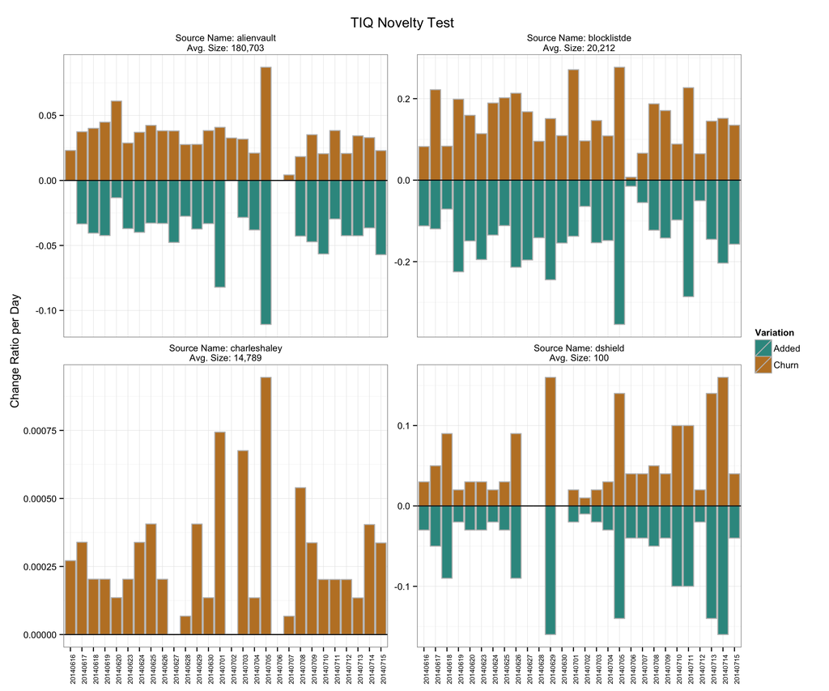

```r
tiq.test.plotNoveltyTest(inbound.novelty)
```

And results running on the outbound data:

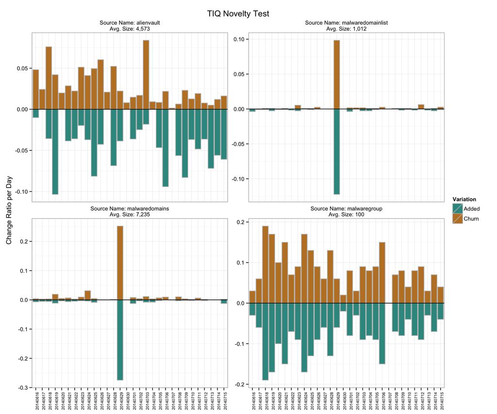

```r
outbound.novelty = tiq.test.noveltyTest("public_outbound", "20140615", "20140715",
                                select.sources=c("alienvault", "malwaregroup",
                                                 "malwaredomainlist", "malwaredomains"),
                                                                         .progress=FALSE)
tiq.test.plotNoveltyTest(outbound.novelty)
```

## Overlap Test

This is an example of applying the Overlap Test to our inbound dataset

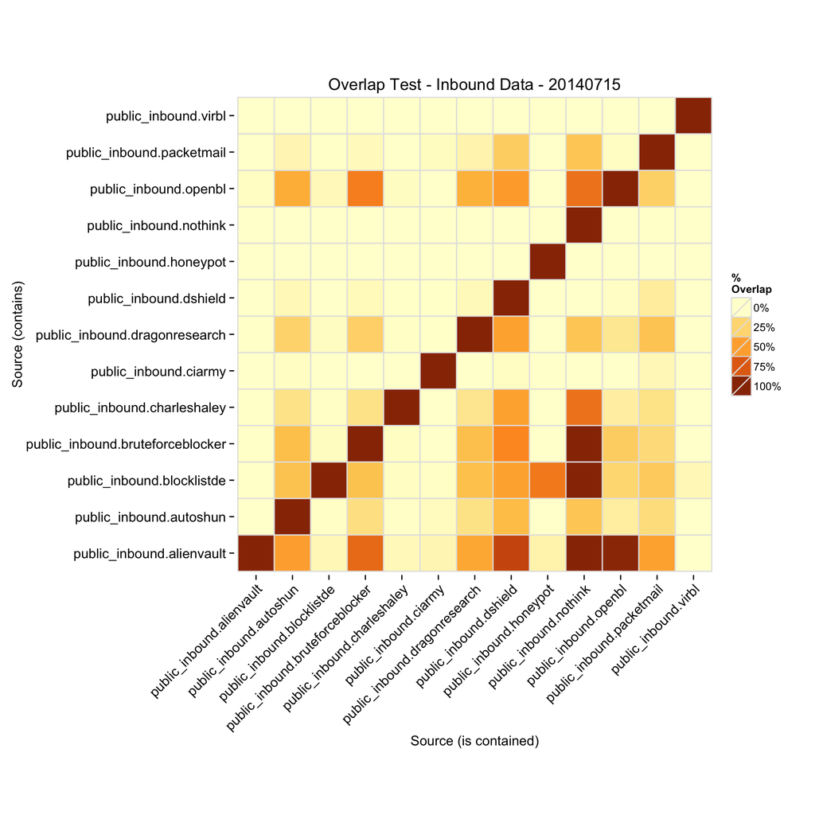

```r
overlap = tiq.test.overlapTest("public_inbound", "20140715", "enriched",
                               select.sources=NULL)
tiq.test.plotOverlapTest(overlap, title="Overlap Test - Inbound Data - 20140715")
```

Similarly, an example applying the Overlap Test to the outbound dataset

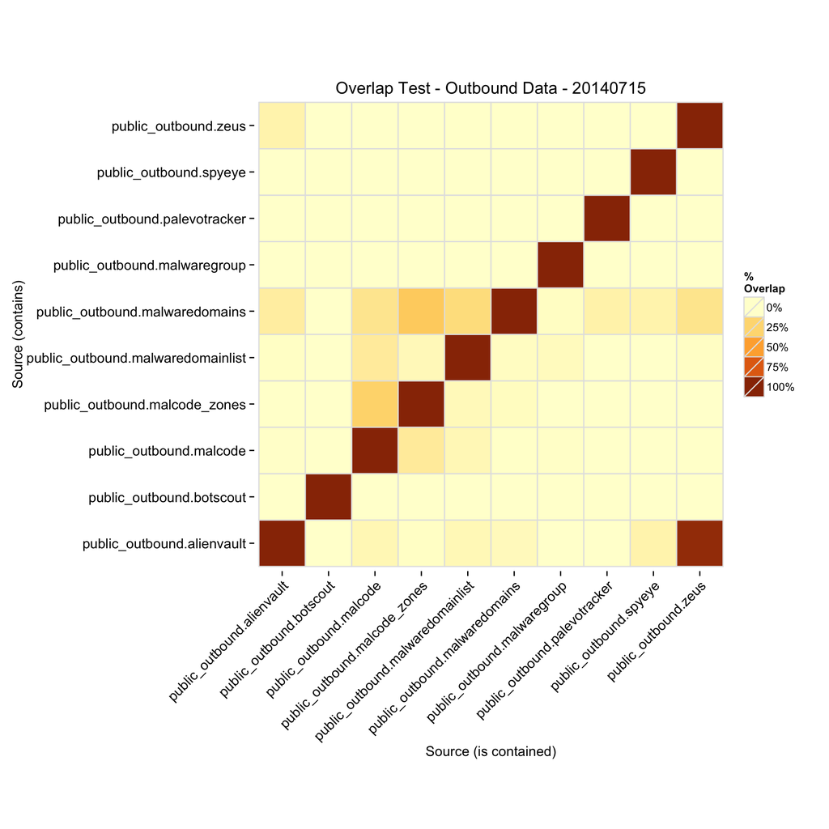

```r
overlap = tiq.test.overlapTest("public_outbound", "20140715", "enriched",
                               select.sources=NULL)
tiq.test.plotOverlapTest(overlap, title="Overlap Test - Outbound Data - 20140715")
```

What about that day when `malwaredomainlist` and `malwaredomains` moved together on the novelty test?

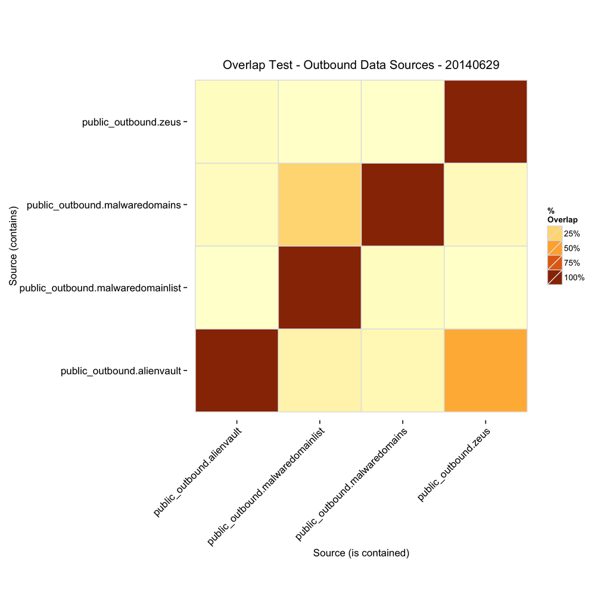

```r
overlap = tiq.test.overlapTest("public_outbound", "20140629", "enriched",
                               select.sources=c("public_outbound.alienvault",
                                                "public_outbound.malwaredomainlist",
                                                "public_outbound.malwaredomains",
                                                "public_outbound.zeus"))
tiq.test.plotOverlapTest(overlap, title="Overlap Test - Outbound Data Sources - 20140629")
```

## Population Test Plots

With the population data we can generate some plot to compare the top quantities of reported IP addresses on a specific date by Country

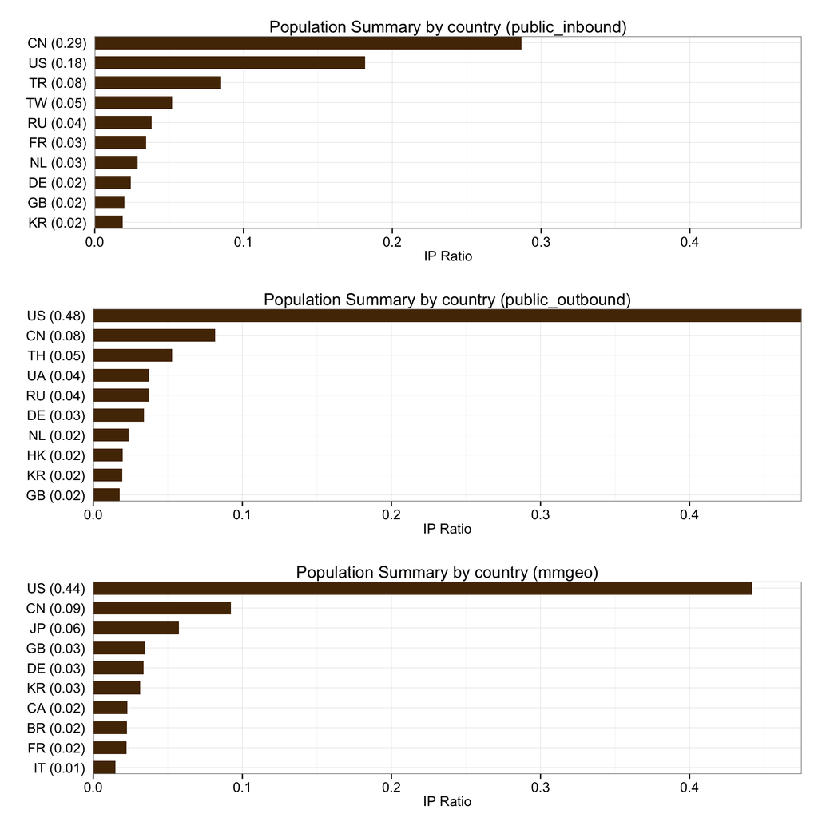

```r
outbound.pop = tiq.test.extractPopulationFromTI("public_outbound", "country",
                                                date = "20140711",
                                                select.sources=NULL, split.ti=F)
inbound.pop = tiq.test.extractPopulationFromTI("public_inbound", "country",
                                               date = "20140711",
                                               select.sources=NULL, split.ti=F)

complete.pop = tiq.data.loadPopulation("mmgeo", "country")
tiq.test.plotPopulationBars(c(inbound.pop, outbound.pop, complete.pop), "country")
```

Or we can compare them by the AS that those IP addresses are a part of. Of course, there is an infinite number of more AS’s then Countries, so the distribution is much more granular.

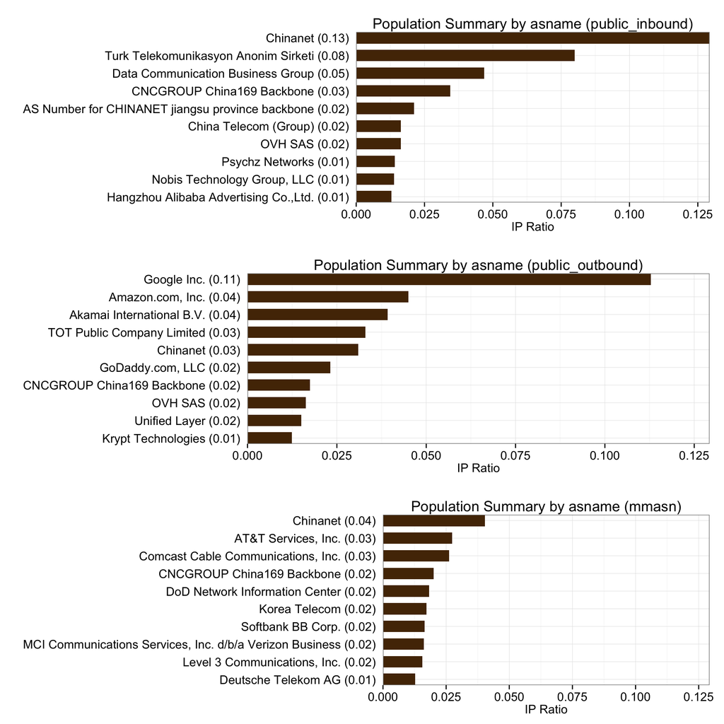

```r
outbound.pop = tiq.test.extractPopulationFromTI("public_outbound",
                                                c("asnumber", "asname"),
                                                date = "20140711",
                                                select.sources=NULL, split.ti=F)
inbound.pop = tiq.test.extractPopulationFromTI("public_inbound",
                                               c("asnumber", "asname"),
                                               date = "20140711",
                                               select.sources=NULL, split.ti=F)

complete.pop = tiq.data.loadPopulation("mmasn", c("asnumber", "asname"))
tiq.test.plotPopulationBars(c(inbound.pop, outbound.pop, complete.pop), "asname")
```

## Population Test Inference - Country data

We can use some inference tools to get a better understanding if the volume of maliciousness we are seeing makes sense in relation to the population we consider to be our reference population.

```r
outbound.pop = tiq.test.extractPopulationFromTI("public_outbound", "country",
                                                date = "20140711",
                                                select.sources=NULL,
                                                split.ti=FALSE)
complete.pop = tiq.data.loadPopulation("mmgeo", "country")
tests = tiq.test.populationInference(complete.pop$mmgeo,
                                     outbound.pop$public_outbound, "country",
                                     exact = TRUE, top=10)

# Whose proportion is bigger than it should be?
tests[p.value < 0.05/10 & conf.int.end > 0][order(conf.int.end, decreasing=T)]
```

```
##    country conf.int.start conf.int.end       p.value
## 1:      TH    0.047043941   0.05415374  0.000000e+00
## 2:      US    0.025334511   0.04111293  9.406044e-17
## 3:      UA    0.031251689   0.03729655  0.000000e+00
## 4:      RU    0.021363061   0.02738814 1.198254e-105
## 5:      HK    0.014238329   0.01868017 2.411914e-128
## 6:      NL    0.007818182   0.01267916  4.091238e-23
```

```r
# Whose is smaller?
tests[p.value < 0.05/10 & conf.int.start < 0][order(conf.int.start, decreasing=F)]
```

```
##    country conf.int.start conf.int.end      p.value
## 1:      GB    -0.01925840 -0.015039734 8.987992e-38
## 2:      CN    -0.01468771 -0.005996168 5.356184e-06
## 3:      KR    -0.01411298 -0.009713368 3.808829e-20
```

```r
# And whose is the same? ¯\_(ツ)_/¯
tests[p.value > 0.05/10]
```

```
##    country conf.int.start conf.int.end   p.value
## 1:      DE   -0.002365533  0.003410789 0.7553375
```

This tool also enables us to do trend comparison between the same TI groupings from different days or between different groupings. A suggested usage is comparing the threat intelligence feeds you have against the population of confirmed attacks or firewall blocks you have in your environment.

```r
outbound.pop2 = tiq.test.extractPopulationFromTI("public_outbound", "country",
                                                 date = "20140712",
                                                 select.sources=NULL,
                                                 split.ti=FALSE)
tests = tiq.test.populationInference(outbound.pop$public_outbound,
                                     outbound.pop2$public_outbound, "country",
                                     exact = F, top=10)

# Whose proportion is bigger than it should be?
tests[p.value < 0.05/10 & conf.int.end > 0][order(conf.int.end, decreasing=T)]
```

```
##    country conf.int.start conf.int.end      p.value
## 1:      TH    0.008891793   0.01948839 1.312399e-07
```

```r
# Whose is smaller?
tests[p.value < 0.05/10 & conf.int.start < 0][order(conf.int.start, decreasing=F)]
```

```
## Empty data.table (0 rows) of 4 cols: country,conf.int.start,conf.int.end,p.value
```

```r
# And whose is the same? ¯\_(ツ)_/¯
tests[p.value > 0.05/10]
```

```
##    country conf.int.start conf.int.end   p.value
## 1:      CN   -0.008903046  0.003230372 0.3651813
## 2:      DE   -0.005626142  0.002421315 0.4460968
## 3:      GB   -0.003825719  0.002054772 0.5752780
## 4:      HK   -0.004286485  0.001887296 0.4611856
## 5:      KR   -0.004004475  0.002129227 0.5681926
## 6:      NL   -0.004471032  0.002307913 0.5483787
## 7:      RU   -0.005538216  0.002877321 0.5489187
## 8:      UA   -0.005499654  0.002946799 0.5675340
## 9:      US   -0.009314533  0.012858212 0.7613027
```

## Population Test Inference - ASN data

```r
outbound.pop = tiq.test.extractPopulationFromTI("public_outbound",
                                                c("asnumber", "asname"),
                                                date="20140711",
                                                select.sources=NULL,
                                                split.ti=FALSE)
complete.pop = tiq.data.loadPopulation("mmasn", c("asnumber", "asname"))
tests = tiq.test.populationInference(complete.pop$mmasn,
                                     outbound.pop$public_outbound,
                                     c("asname", "asnumber"),
                                     exact = TRUE, top=10)

# Whose proportion is bigger than it should be?
tests[p.value < 0.05/10 & conf.int.end > 0][order(conf.int.end, decreasing=T)]
```

```
##                        asname conf.int.start conf.int.end       p.value
## 1:                Google Inc.     0.10755968   0.11758122  0.000000e+00
## 2:           Amazon.com, Inc.     0.04014565   0.04673365  0.000000e+00
## 3:  Akamai International B.V.     0.03534266   0.04151424  0.000000e+00
## 4: TOT Public Company Limited     0.03019134   0.03587838  0.000000e+00
## 5:           GoDaddy.com, LLC     0.02051937   0.02531653  0.000000e+00
## 6:                    OVH SAS     0.01396927   0.01802138 1.046140e-302
## 7:              Unified Layer     0.01292421   0.01681818 7.410985e-323
## 8:         Krypt Technologies     0.01049485   0.01404077 8.007489e-265
```

```r
# Whose is smaller?
tests[p.value < 0.05/10 & conf.int.start < 0][order(conf.int.start, decreasing=F)]
```

```
##      asname conf.int.start conf.int.end      p.value
## 1: Chinanet    -0.01216286 -0.006648442 4.902953e-10
```

```r
# And whose is the same? ¯\_(ツ)_/¯
tests[p.value > 0.05/10]
```

```
##                        asname conf.int.start  conf.int.end    p.value
## 1: CNCGROUP China169 Backbone   -0.004651431 -0.0004625131 0.01762452
```

This huge prevalence of Google AS IPs should be investigated further. Some of it could be from parking at `8.8.8.8` and `1.1.1.1` but it seems to be too much

```r
outbound.ti = tiq.data.loadTI("enriched", "public_outbound", "20140711")
outbound.ti[asname %like% "Google",  list(entity, type, source, asname, host)]
```

```
##               entity type         source      asname                 host
##    1:  74.125.228.43 IPv4        malcode Google Inc.                   NA
##    2:  74.125.228.75 IPv4        malcode Google Inc.                   NA
##    3: 173.194.115.16 IPv4  malcode_zones Google Inc.       googleapis.com
##    4: 173.194.115.17 IPv4  malcode_zones Google Inc.       googleapis.com
##    5: 173.194.115.18 IPv4  malcode_zones Google Inc.       googleapis.com
##   ---
## 1964:        8.8.8.8 IPv4 malwaredomains Google Inc.        revlister.com
## 1965:        8.8.8.8 IPv4 malwaredomains Google Inc.        statalyze.net
## 1966:        8.8.8.8 IPv4 malwaredomains Google Inc.   statisticbench.net
## 1967:        8.8.8.8 IPv4 malwaredomains Google Inc.      webdestinct.net
## 1968:        8.8.8.8 IPv4         spyeye Google Inc. futuretelefonica.com
```

```r
outbound.ti[asname %like% "Google" & entity != "8.8.8.8" & entity != "1.1.1.1",
            list(entity, type, source, asname, host)]
```

```
##               entity type         source      asname              host
##    1:  74.125.228.43 IPv4        malcode Google Inc.                NA
##    2:  74.125.228.75 IPv4        malcode Google Inc.                NA
##    3: 173.194.115.16 IPv4  malcode_zones Google Inc.    googleapis.com
##    4: 173.194.115.17 IPv4  malcode_zones Google Inc.    googleapis.com
##    5: 173.194.115.18 IPv4  malcode_zones Google Inc.    googleapis.com
##   ---
## 1950:  74.125.70.101 IPv4 malwaredomains Google Inc. chrome.google.com
## 1951:  74.125.70.102 IPv4 malwaredomains Google Inc. chrome.google.com
## 1952:  74.125.70.113 IPv4 malwaredomains Google Inc. chrome.google.com
## 1953:  74.125.70.138 IPv4 malwaredomains Google Inc. chrome.google.com
## 1954:  74.125.70.139 IPv4 malwaredomains Google Inc. chrome.google.com
```

I guess it is fair to say that it would be a good idea to cleanup these feeds. :)

That’s all for now, folks! Feel free to suggest new tests and experiments!